# Unit4HW

Shon Mohsin

June 4, 2018

Questions 1. FiveThirtyEight Data (30 points): Navigate on GitHub to https://github.com/rudeboybert/fivethirtyeight and read README.md. Seriously, it will include every command you need. Test out some commands on R. a. Install the fivethirtyeight package. b. In the listing of Data sets in package ‘fivethirtyeight,’ assign the eighteenth data set to an object ‘df.’

```r
library(ggplot2)
library(fivethirtyeight)
df<- college_recent_grads
summary(df)
```

```
##       rank       major_code      major           major_category
##  Min.   :  1   Min.   :1100   Length:173         Length:173
##  1st Qu.: 44   1st Qu.:2403   Class :character   Class :character
##  Median : 87   Median :3608   Mode  :character   Mode  :character
##  Mean   : 87   Mean   :3880
##  3rd Qu.:130   3rd Qu.:5503
##  Max.   :173   Max.   :6403
##
##      total         sample_size          men             women
##  Min.   :   124   Min.   :   2.0   Min.   :   119   Min.   :     0
##  1st Qu.:  4550   1st Qu.:  39.0   1st Qu.:  2178   1st Qu.:  1778
##  Median : 15104   Median : 130.0   Median :  5434   Median :  8386
##  Mean   : 39370   Mean   : 356.1   Mean   : 16723   Mean   : 22647
##  3rd Qu.: 38910   3rd Qu.: 338.0   3rd Qu.: 14631   3rd Qu.: 22554
##  Max.   :393735   Max.   :4212.0   Max.   :173809   Max.   :307087
##  NA's   :1                         NA's   :1        NA's   :1
##    sharewomen        employed      employed_fulltime employed_parttime
##  Min.   :0.0000   Min.   :     0   Min.   :   111    Min.   :     0
##  1st Qu.:0.3360   1st Qu.:  3608   1st Qu.:  3154    1st Qu.:  1030
##  Median :0.5340   Median : 11797   Median : 10048    Median :  3299
##  Mean   :0.5222   Mean   : 31193   Mean   : 26029    Mean   :  8832
##  3rd Qu.:0.7033   3rd Qu.: 31433   3rd Qu.: 25147    3rd Qu.:  9948
##  Max.   :0.9690   Max.   :307933   Max.   :251540    Max.   :115172
##  NA's   :1
##  employed_fulltime_yearround   unemployed    unemployment_rate
##  Min.   :   111              Min.   :    0   Min.   :0.00000
##  1st Qu.:  2453              1st Qu.:  304   1st Qu.:0.05031
##  Median :  7413              Median :  893   Median :0.06796
##  Mean   : 19694              Mean   : 2416   Mean   :0.06819
##  3rd Qu.: 16891              3rd Qu.: 2393   3rd Qu.:0.08756
##  Max.   :199897              Max.   :28169   Max.   :0.17723
##
##      p25th           median           p75th         college_jobs
##  Min.   :18500   Min.   : 22000   Min.   : 22000   Min.   :     0
##  1st Qu.:24000   1st Qu.: 33000   1st Qu.: 42000   1st Qu.:  1675
##  Median :27000   Median : 36000   Median : 47000   Median :  4390
##  Mean   :29501   Mean   : 40151   Mean   : 51494   Mean   : 12323
##  3rd Qu.:33000   3rd Qu.: 45000   3rd Qu.: 60000   3rd Qu.: 14444
##  Max.   :95000   Max.   :110000   Max.   :125000   Max.   :151643
##
##  non_college_jobs low_wage_jobs
##  Min.   :     0   Min.   :    0
##  1st Qu.:  1591   1st Qu.:  340
##  Median :  4595   Median : 1231
##  Mean   : 13284   Mean   : 3859
##  3rd Qu.: 11783   3rd Qu.: 3466
##  Max.   :148395   Max.   :48207
##
```

3. Use a more detailed list of the data sets to write out the URL in a comment to the related news story.

```r
url1<- vignette("fivethirtyeight", package = "fivethirtyeight")
url1
```

```
## starting httpd help server ... done
```

4. Using R command(s), give the dimensions and column names of this data frame.

```r
dim(df)
```

```
## [1] 173  21
```

2. Data Summary (30 points): Use your newly assigned data frame for Question 2.
1. Write an R command that gives you the column names of the data frame. Right after that, write one that counts the number of columns but not rows. Hint: The number should match one of your numbers in Question 1d for dimensions.

```r
colnames(df)
```

```
##  [1] "rank"                        "major_code"
##  [3] "major"                       "major_category"
##  [5] "total"                       "sample_size"
##  [7] "men"                         "women"
##  [9] "sharewomen"                  "employed"
## [11] "employed_fulltime"           "employed_parttime"
## [13] "employed_fulltime_yearround" "unemployed"
## [15] "unemployment_rate"           "p25th"
## [17] "median"                      "p75th"
## [19] "college_jobs"                "non_college_jobs"
## [21] "low_wage_jobs"
```

```r
colcount <-colnames(df)
sum(lengths(gregexpr("[A-z]\\W+", colcount)))
```

```
## [1] 21
```

2. Generate a count of each unique major_category in the data frame. I recommend using libraries to help. I have demonstrated one briefly in live-session. To be clear, this should look like a matrix or data frame containing the major_category and the frequency it occurs in the dataset. Assign it to major_count.

```r
majorcount <- unique(df$major_category)
major_count <-lengths(majorcount)
major_count <-as.matrix(table(major_count))
major_count
```

```
##   [,1]
## 1   16
```

3. To make things easier to read, enter par(las=2) before your plot to make the text perpendicular to the axis. Make a barplot of major_count. Make sure to label the title with something informative (check the vignette if you need), label the x and y axis, and make it any color other than grey. Assign the major_category labels to their respective bar. Flip the barplot horizontally so that bars extend to the right, not upward. All of these options can be done in a single pass of barplot(). Note: It’s okay if it’s wider than the preview pane.

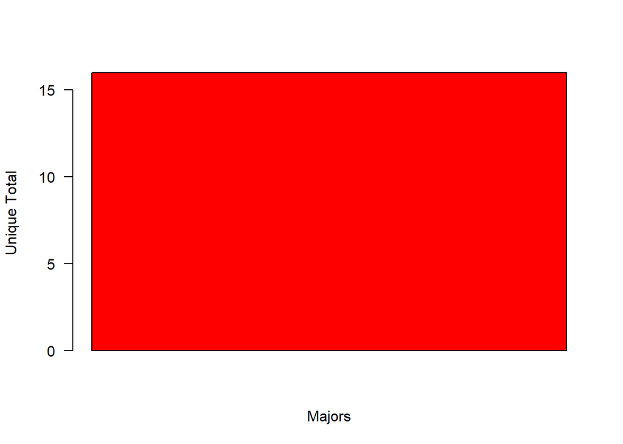

```r
barplotofmajors <-barplot(major_count, xlab= "Majors", ylab= "Unique Total", col=2, las=2)
```

```r
barplotofmajors
```

```
## [1] 0.7
```

4. Write the fivethirtyeight data to a csv file. Make sure that it does not have row labels.

```r
write.csv(df, "collegemajors.csv", row.names=FALSE)
```

3. Codebook (30 points):
1. Start a new repository on GitHub for your SMU MSDS homework. On your local device, make sure there is a directory for Homework at the minimum; you are welcome to add whatever you would like to this repo in addition to your requirements here.
2. Create a README.md file which explains the purpose of the repository, the topics included, the sources for the material you post, and contact information in case of questions. Remember, the one in the root directory should be general. You are welcome to make short READMEs for each assignment individually in other folders.
3. In one (or more) of the nested directories, post your RMarkdown script, HTML file, and data from ‘fivethirtyeight.’ Make sure that in your README or elsewhere that you credit fivethirtyeight in some way.
4. In your RMarkdown script, please provide the link to this GitHub so the grader can see it.

https://github.com/ShonTM/Unit4sync/tree/master/Homework

4. Swirl (10 points): Complete Module 15 in the R Programming course of Swirl. Copy your code/output to a separate .txt file. It does not need to be included in your RMarkdown file. The grader has requested at minimum to show the 90%-100% progress bar for the module and what output you had for it.
1. Complete “15: Graphics Basics” Reminder

To complete this assignment, please submit one RMarkdown and matching HTML file that includes questions 1-2, and a .txt file containing solely your swirl output (Question 4) at least one hour before your live session on September 27, 2017. You do not need to submit a link to your GitHub: just note where it is in your RMarkdown file. Make sure it is public!! Please submit all files at the same time; only one submission is granted. Good luck!